# iHeartMediaDataAnalystChallenge

```python
#loading up all necessary libraries
import warnings
warnings.filterwarnings("ignore")
import pandas as pd
import numpy as np
import matplotlib.pyplot as plt
import seaborn as sns
import random #for repeatability purpose
random.seed(4)
from sklearn.ensemble import IsolationForest #AI assist suggestion
```

```python
#Loading data
file_path= "iHeart Test - Data File.xlsx"
df= pd.read_excel(file_path)

# Preview first few rows and basic info
df.head(), df.info()
```

```
<class 'pandas.core.frame.DataFrame'>
RangeIndex: 299996 entries, 0 to 299995
Data columns (total 12 columns):
Year of Order Created       299996 non-null int64
Month of Order Created      299996 non-null object
Week of Order Created       299996 non-null object
Date Order Created          299996 non-null object
Order ID                    299996 non-null int64
Order Type                  299996 non-null object
Market                      298947 non-null object
Advertiser                  299996 non-null object
Sales Lead                  299996 non-null object
Product                     299996 non-null object
Sales Order Line Item ID    296918 non-null float64
Sum of Gross Revenue        299996 non-null int64
dtypes: float64(1), int64(3), object(8)
memory usage: 27.5+ MB
```

```
(   Year of Order Created Month of Order Created Week of Order Created  \
 0                   2023               February                Week 5
 1                   2023               February                Week 6
 2                   2023                January                Week 2
 3                   2023                  March               Week 13
 4                   2023               February                Week 8

     Date Order Created     Order ID Order Type        Market  \
 0  2023-02-02 00:00:00  19000794299      Local  SaintLouisMO
 1  2023-02-07 00:00:00  19000797077      Local      AustinTX
 2  2023-01-12 00:00:00  19000780099      Local   EauClaireWI
 3  2023-03-25 00:00:00  19000828120      Local  CincinnatiOH
 4  2023-02-22 00:00:00  19000805985      Local   CharlotteNC

          Advertiser   Sales Lead    Product  Sales Order Line Item ID  \
 0   Advertiser 2892  Seller 1351  Broadcast                 7241057.0
 1   Advertiser 1919  Seller 1361  Broadcast                 6107523.0
 2   Advertiser 3701   Seller 571  Broadcast                 5610380.0
 3  Advertiser 14728   Seller 666  Broadcast                 6874548.0
 4      Advertiser 2   Seller 893  Broadcast                 7738572.0

    Sum of Gross Revenue
 0                     1
 1                     1
 2                    91
 3                   151
 4                   226  , None)
```

```python
df.columns.values
```

```
array(['Year of Order Created', 'Month of Order Created',
       'Week of Order Created', 'Date Order Created', 'Order ID',
       'Order Type', 'Market', 'Advertiser', 'Sales Lead', 'Product',
       'Sales Order Line Item ID', 'Sum of Gross Revenue'], dtype=object)
```

```python
df.describe()
```

|  | Year of Order Created | Order ID | Sales Order Line Item ID | Sum of Gross Revenue |
| --- | --- | --- | --- | --- |
| count | 299996.0 | 2.999960e+05 | 2.969180e+05 | 299996.000000 |
| mean | 2023.0 | 1.900080e+10 | 6.537481e+06 | 726.866408 |
| std | 0.0 | 1.856369e+04 | 1.626541e+06 | 3516.095928 |
| min | 2023.0 | 1.900077e+10 | 7.990000e+03 | 1.000000 |
| 25% | 2023.0 | 1.900079e+10 | 5.622300e+06 | 1.000000 |
| 50% | 2023.0 | 1.900080e+10 | 6.412256e+06 | 105.000000 |
| 75% | 2023.0 | 1.900082e+10 | 7.663105e+06 | 461.000000 |
| max | 2023.0 | 1.900083e+10 | 1.154933e+07 | 389460.000000 |

The above shows the basic statistics before any clean up. This should not be affected much with the cleanup. The stats are only focused on Numerical category, but Order ID can be ignored as it is essentially a categorical category. The main focus is Sum of Gross Revenue, which shows the average of revenue at 726.87 USD. With a max count of 389,460 USD representing the maximum revenue iHeartMedia received from a transaction.

```python
#Data Quality Check

# Clean up "fake nulls"
df = df.replace(["", " ", "NA", "N/A", "NULL", "null"], np.nan)

def data_quality_report(df, cols):
    report = pd.DataFrame({
        "Column": cols,
        "Missing Count": [df[c].isna().sum() for c in cols],
        "Missing %": [df[c].isna().mean() * 100 for c in cols]
    })
    return report

# Run for key columns again
quality_report = data_quality_report(df, ["Market", "Product", "Sales Order Line Item ID"])
print("Data Quality Report:\n", quality_report)

# Save to Excel for sharing- ignoring for now as the data is already marked in excel
# with pd.ExcelWriter("data_quality_summary.xlsx") as writer:
#     quality_report.to_excel(writer, sheet_name="Missing Stats", index=False)
```

```
Data Quality Report:
                      Column  Missing Count  Missing %
0                    Market           1049   0.349671
1                   Product           3078   1.026014
2  Sales Order Line Item ID           3078   1.026014
```

Noting that excel shows a higher missing counts, regardless of multiple different ways to check with Python. This is most likely because Excel may be because of how Excel counts blank ranges vs true missing values.

```python
#Data Cleaning

# Convert date
df["Date Order Created"] = pd.to_datetime(df["Date Order Created"], errors="coerce")

# Drop ALL rows with missing values in ANY column
before_rows = df.shape[0]
df = df.dropna()
after_rows = df.shape[0]

print(f"Rows before cleanup: {before_rows}")
print(f"Rows after cleanup: {after_rows}")
print(f"Rows dropped: {before_rows - after_rows} ({((before_rows - after_rows)/before_rows)*100:.2f}%)")

df.head()
```

```
Rows before cleanup: 299996
Rows after cleanup: 291685
Rows dropped: 8311 (2.77%)
```

|  | Year of Order Created | Month of Order Created | Week of Order Created | Date Order Created | Order ID | Order Type | Market | Advertiser | Sales Lead | Product | Sales Order Line Item ID | Sum of Gross Revenue |
| --- | --- | --- | --- | --- | --- | --- | --- | --- | --- | --- | --- | --- |
| 0 | 2023 | February | Week 5 | 2023-02-02 | 19000794299 | Local | SaintLouisMO | Advertiser 2892 | Seller 1351 | Broadcast | 7241057.0 | 1 |
| 1 | 2023 | February | Week 6 | 2023-02-07 | 19000797077 | Local | AustinTX | Advertiser 1919 | Seller 1361 | Broadcast | 6107523.0 | 1 |
| 2 | 2023 | January | Week 2 | 2023-01-12 | 19000780099 | Local | EauClaireWI | Advertiser 3701 | Seller 571 | Broadcast | 5610380.0 | 91 |
| 3 | 2023 | March | Week 13 | 2023-03-25 | 19000828120 | Local | CincinnatiOH | Advertiser 14728 | Seller 666 | Broadcast | 6874548.0 | 151 |
| 4 | 2023 | February | Week 8 | 2023-02-22 | 19000805985 | Local | CharlotteNC | Advertiser 2 | Seller 893 | Broadcast | 7738572.0 | 226 |

Row count went from 299,996 to 291,685 after dropping all NAN and Null values. Total of 2.77% of rows were dropped so we still have over ~97% of data to work with.

```python
# Save cleaned data for Tableau
df.to_csv("cleaned_revenue_data.csv", index=False)
```

```python
#Show count of each category in the order type column:
order_type_counts = df['Order Type'].value_counts()
print(order_type_counts)
```

```
Local           275874
MMP              14844
National           960
National MMP         7
Name: Order Type, dtype: int64
```

```python
# Helper function: get top 5 for a given column grouped by Order Type
def top_by_order_type(df, group_col, value_col="Sum of Gross Revenue", top_n=10):
    result = (
        df.groupby(["Order Type", group_col])[value_col]
          .sum()
          .reset_index()
          .sort_values(["Order Type", value_col], ascending=[True, False])
          .groupby("Order Type")
          .head(top_n)
    )
    return result

# Top 10 Markets by Order Type
top_markets = top_by_order_type(df, "Market")

# Top 10 Advertisers by Order Type
top_advertisers = top_by_order_type(df, "Advertiser")

# Top 10 Sellers by Order Type
top_sellers = top_by_order_type(df, "Sales Lead")

# Top 10 Products by Order Type
top_products = top_by_order_type(df, "Product")

# Revenue by Order Type (overall)
rev_by_order_type = df.groupby("Order Type")["Sum of Gross Revenue"].sum().reset_index()

# Display previews
print("Top Markets by Order Type:\n", top_markets.head(10))
print("\nTop Advertisers by Order Type:\n", top_advertisers.head(10))
print("\nTop Sellers by Order Type:\n", top_sellers.head(10))
print("\nTop Products by Order Type:\n", top_products.head(10))
print("\nRevenue by Order Type:\n", rev_by_order_type)
```

```
Top Markets by Order Type:
     Order Type        Market  Sum of Gross Revenue
151      Local  LosAngelesCA              13732934
191      Local     NewYorkNY               6767008
129      Local     HoustonTX               5865715
58       Local  CincinnatiOH               4941702
264      Local       TampaFL               4543304
245      Local    SanDiegoCA               4521632
81       Local      DenverCO               4064903
209      Local     PhoenixAZ               3768607
54       Local     ChicagoIL               3736017
68       Local    ColumbusOH               3446156

Top Advertisers by Order Type:
       Order Type       Advertiser  Sum of Gross Revenue
```

[output cut: 43 more lines]

The data above shows how Advertiser, seller, and product's relationship with the order type. It also shows the total revenue each order type generates, with Local having the highest revenue and National MMP having the least- this somewhat makes sense as the count of National MMP is the lowest, while Local is the highest.

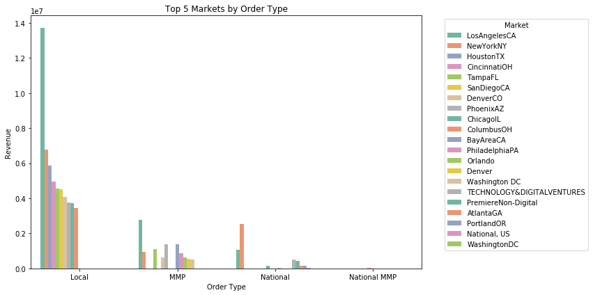

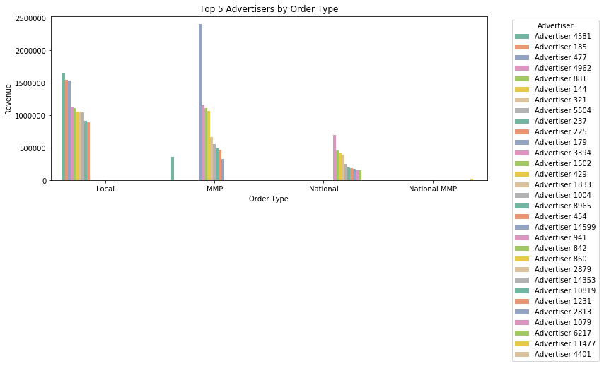

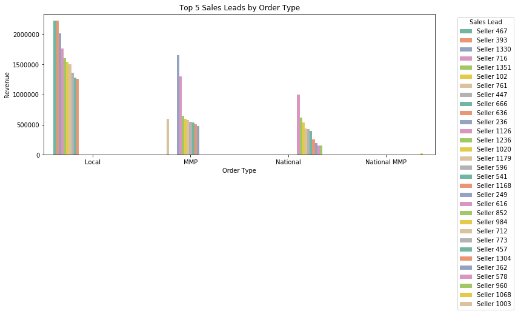

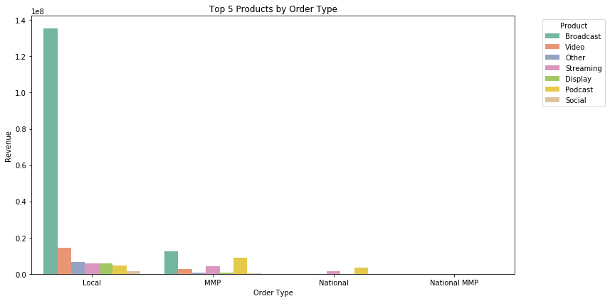

```python
# Helper plotting function -AI assist for Visual
def plot_top_by_order_type(df, group_col, title):
    plt.figure(figsize=(12,6))
    sns.barplot(
        data=df,
        x="Order Type",
        y="Sum of Gross Revenue",
        hue=group_col,
        palette="Set2"
    )
    plt.title(f"Top 5 {group_col}s by Order Type")
    plt.ylabel("Revenue")
    plt.xlabel("Order Type")
    plt.legend(title=group_col, bbox_to_anchor=(1.05, 1), loc="upper left")
    plt.tight_layout()
    plt.show()

# Plot each
plot_top_by_order_type(top_markets, "Market", "Markets")
plot_top_by_order_type(top_advertisers, "Advertiser", "Advertisers")
plot_top_by_order_type(top_sellers, "Sales Lead", "Sellers")
plot_top_by_order_type(top_products, "Product", "Products")
```

For Local market, the focus should be on LA, NYC and Houston, as these 3 have the highest revenue. For MMP, it should focus on LA, followed by Pheonix and then Bay Area, CA. Lastly for national, we should implement a better identifier that can categorize the Unknown category (for whatever reason, when reruning the notebook, Unknown was replaced with TECHNOLOGY&DIGITALVENTURES). This will help with better targeting on a National level. If we take into account the Local trend, the National should be similar.

For products, at Local and MMP level, Broadcast performs best. For local it makes sense as broadcast is the easiest way to reach the most users. While broadcast is still the best for MMP, Podcast is not far behind, showing that multi-market partnership has a strong growth with podcast. The same rule applies to National for Podcast, and streaming which lines up with easier access due to internet accesibility.

##### Noting that National MMP was excluded for all above, as it does not show any significance revenue possibility.

```
Bottom 5 Advertisers by order type:
          Order Type        Advertiser  Sum of Gross Revenue
65            Local  Advertiser 10066                     1
107           Local  Advertiser 10112                     1
203           Local  Advertiser 10222                     1
226           Local  Advertiser 10248                     1
245           Local  Advertiser 10267                     1
13197           MMP  Advertiser 11096                     1
13226           MMP  Advertiser 11726                     1
13245           MMP  Advertiser 12060                     1
13265           MMP  Advertiser 12445                     1
13277           MMP  Advertiser 12715                     1
13979      National   Advertiser 6963                     5
13974      National   Advertiser 5760                   501
13951      National  Advertiser 13225                  2958
```

[output cut: 43 more lines]

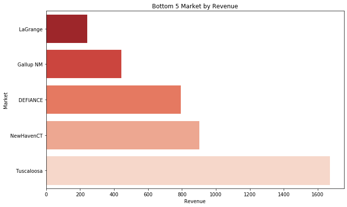

```python
# Helper function: get bottom N for a given column grouped by Order Type
def bottom_by_order_type(df, group_col, value_col="Sum of Gross Revenue", bottom_n=5):
    result = (
        df.groupby(["Order Type", group_col])[value_col]
          .sum()
          .reset_index()
          .sort_values(["Order Type", value_col], ascending=[True, True])  # ascending=True keeps lowest first
          .groupby("Order Type")
          .head(bottom_n)
    )
    return result

# Bottom 5 Markets by Order Type
bottom_markets = bottom_by_order_type(df, "Market")

# Bottom 5 Advertisers by Order Type
bottom_advertisers = bottom_by_order_type(df, "Advertiser")
print('Bottom 5 Advertisers by order type: \n', bottom_advertisers)

# Bottom 5 Sellers by Order Type
bottom_sellers = bottom_by_order_type(df, "Sales Lead")
print('Bottom 5 Sellers by order type: \n', bottom_sellers)

# # Bottom 5 Products by Order Type
bottom_products = bottom_by_order_type(df, "Product")
print('Bottom 5 Products by order type: \n', bottom_products)

# -------------------------------
# Visualize Bottom 5 Example
# -------------------------------


def plot_bottom(df, group_col, title, bottom_n=5):
    subset = (
        df.groupby([group_col])["Sum of Gross Revenue"]
          .sum()
          .nsmallest(bottom_n)
          .reset_index()
    )

    plt.figure(figsize=(10,6))
    sns.barplot(data=subset, x="Sum of Gross Revenue", y=group_col, palette="Reds_r")
    plt.title(f"Bottom {bottom_n} {group_col} by Revenue")
    plt.xlabel("Revenue")
    plt.ylabel(group_col)
    plt.tight_layout()
    plt.show()

# Example: Bottom 10 Markets
plot_bottom(df, "Market", "Bottom Markets by Revenue", bottom_n=5)
```

The above is just a small output to show the bottom performing. This can be analyzed later if we want to look at and remove bottom performers in the future

```
Top 10 Markets:
 Market
LosAngelesCA    17563431
NewYorkNY       10229038
HoustonTX        6197823
TampaFL          5635492
PhoenixAZ        5167061
CincinnatiOH     5071337
SanDiegoCA       5019204
DenverCO         4700155
ChicagoIL        4162240
MiamiFL          3655598
Name: Sum of Gross Revenue, dtype: int64
```

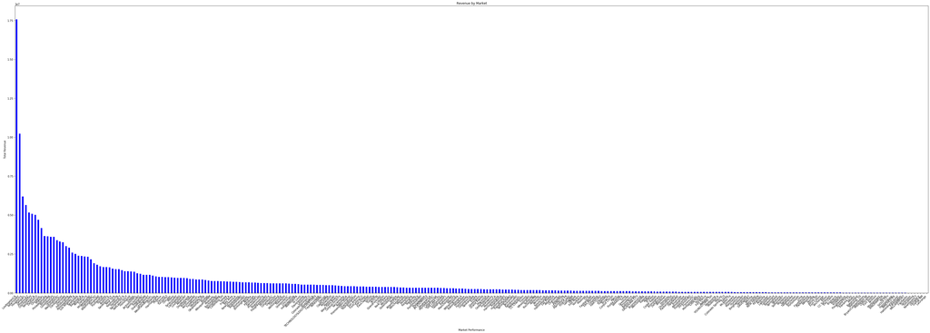

```python
#Revenue by Market Analysis

market_perf= df.groupby("Market")["Sum of Gross Revenue"].sum().sort_values(ascending=False)
print("Top 10 Markets: \n", market_perf.head(10))
market_perf.plot(kind="bar", figsize= (50,18), color= "blue")
plt.title("Revenue by Market")
plt.xlabel("Market Performance")
plt.xticks(rotation=45, ha="right")
plt.tight_layout()
plt.ylabel("Total Revenue")
plt.show()
```

```
Top 5 Products:
 Product
Broadcast    148082772
Podcast       17285768
Video         17079015
Streaming     11763382
Other          6974253
Name: Sum of Gross Revenue, dtype: int64
```

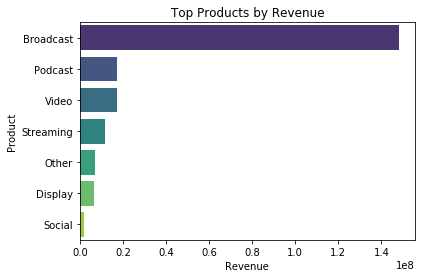

```python
# Revenue by Product
product_perf = df.groupby("Product")["Sum of Gross Revenue"].sum().sort_values(ascending=False)
print("Top 5 Products: \n", product_perf.head(5))
sns.barplot(x=product_perf.values, y=product_perf.index, palette="viridis")
plt.title("Top Products by Revenue")
plt.xlabel("Revenue")
plt.ylabel("Product")
plt.show()
```

This simply shows a visual of top 5 products by revenue. Just like the order type, this shows that broadcasting has the best reach, but podcast and streaming (including video) shows potential for higher revenue growth. Require more than just 3 months of data to validate this reasoning.

```
Revenue Per Month:
 Date Order Created
2023-01    81659767
2023-02    57046325
2023-03    70688721
Freq: M, Name: Sum of Gross Revenue, dtype: int64
```

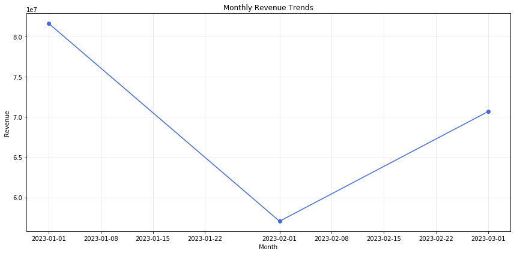

```python
#Revenue trends over time

monthly_rev= df.groupby(df["Date Order Created"].dt.to_period("M"))["Sum of Gross Revenue"].sum()
print("Revenue Per Month: \n", monthly_rev)
monthly_rev.index = monthly_rev.index.to_timestamp()   # convert Period → Timestamp for plotting
plt.figure(figsize=(12,6))
plt.plot(monthly_rev.index, monthly_rev.values, marker="o", color="royalblue")
plt.title("Monthly Revenue Trends")
plt.xlabel("Month")
plt.ylabel("Revenue")
plt.grid(alpha=0.3)
plt.tight_layout()
plt.show()
```

This simply shows monthly revenue trend. It shows highest revenue in the beginning of the year, which would makes sense if we take into account that the holidays just ended and it is rollover from prior months. The dip in February could attributes to lower activities in the month of January due to the start of the New Year and this is when generally everything is on a more "relaxed" state of affair. But the trend shows more activity from February onward showing higher interaction with producs, therefor more revenue as the quarter kicks into full gear. Require more data to validate the reasoning.

```
 Top 10 Advertiser by Revenue:
  Advertiser
Advertiser 179     2412463
Advertiser 4581    1997857
Advertiser 185     1543220
Advertiser 477     1531403
Advertiser 1833    1490797
Advertiser 429     1249010
Advertiser 3394    1152880
Advertiser 4962    1126065
Advertiser 1502    1124194
Advertiser 881     1110372
Name: Sum of Gross Revenue, dtype: int64
```

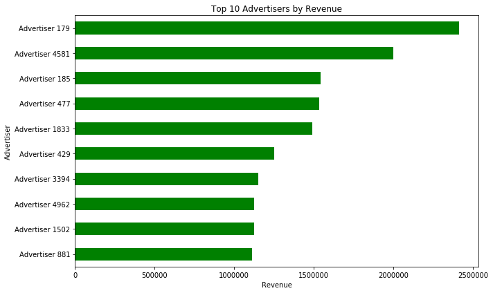

```python
#Revenue by Advertiser

advertiser_rev= df.groupby("Advertiser")["Sum of Gross Revenue"].sum().sort_values(ascending=False)
#Show the top 10 Advertiser
#- I tired running a visual of all advertiser but it would take too long. Might require cloud computing for faster output
top_ten_advertiser= advertiser_rev.head(10)
print(" Top 10 Advertiser by Revenue:\n ", top_ten_advertiser)
plt.figure(figsize=(10,6))
top_ten_advertiser.plot(kind="barh", color="green")
plt.title("Top 10 Advertisers by Revenue")
plt.xlabel("Revenue")
plt.ylabel("Advertiser")
# This line inverts the y-axis so the highest value is at the top
plt.gca().invert_yaxis()
plt.tight_layout()
plt.show()
```

Due to the MMP category, as well as respective performance in the Local category, Advertiser 179 takes the lead in driving revenue, followed closely by 4581, which was the highest revenue in the Local category. Adveriser 185 and 477 follows the same trend as the Local level. We should take a closer look into the performance of Advertiser 179 at the MMP level to better understand and implement same rules to the other high performing Local level advertisers.

```
Top 10 Sellers by Revenue:
 Sales Lead
Seller 467     2552329
Seller 393     2451099
Seller 1330    2370947
Seller 761     2100171
Seller 1351    1788783
Seller 716     1784695
Seller 236     1706109
Seller 1016    1649883
Seller 636     1643164
Seller 102     1544442
Name: Sum of Gross Revenue, dtype: int64
```

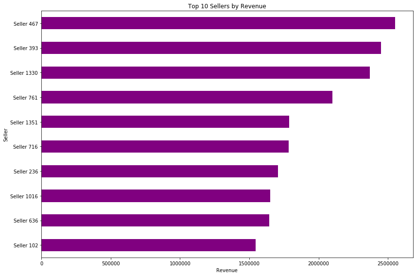

```python
#Revenue by Seller

# Revenue by Advertiser

seller_rev = df.groupby("Sales Lead")["Sum of Gross Revenue"].sum().sort_values(ascending=False)

# Get only the top 10 advertisers for plotting
top_10_seller = seller_rev.head(10)

print("Top 10 Sellers by Revenue:\n", top_10_seller)

plt.figure(figsize=(12, 8))
top_10_seller.plot(kind="barh", color="purple")
plt.title("Top 10 Sellers by Revenue")
plt.xlabel("Revenue")
plt.ylabel("Seller")
plt.gca().invert_yaxis()  # Invert y-axis to show the highest value on top
plt.tight_layout()
plt.show()
```

This graph lines up with the order type graphs. I belive the same reasoning should follow. A stronger push on Local, but also focus on the MMP order type to see if there is possibility of hidden increase of revenue growth.

### AI Support Analysis

[figure not shown]

```python
# Train isolation forest
clf = IsolationForest(contamination=0.01, random_state=42)
df["anomaly"] = clf.fit_predict(df[["Sum of Gross Revenue"]])

# Count anomalies per market
outlier_counts = df.groupby("Market")["Sum of Gross Revenue"].count().sort_values(ascending=False).head(15)

# Bar chart
plt.figure(figsize=(10,6))
sns.barplot(x=outlier_counts.index, y=outlier_counts.values, color="red")
plt.title("Markets with Most AI-Flagged Revenue Outliers")
plt.ylabel("Number of Anomalies")
plt.xlabel("Market")
plt.xticks(rotation=45, ha="right")
plt.tight_layout()
plt.show()
```